# Taller final Seguridad de la Información

2022-11-03

## **Taller 1.2.1.3**

**Lab - Compare Data with a Hash**

[figure not shown]

## **2**

**Lab - Compare Data with a Hash**

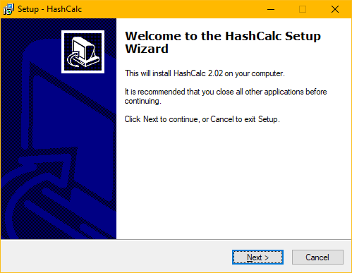

## **3**

**Lab - Compare Data with a Hash**

[figure not shown]

## **4**

**Lab - Compare Data with a Hash**

[figure not shown]

## **5**

**Lab - Compare Data with a Hash**

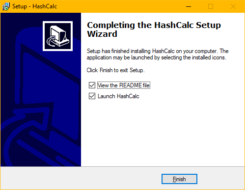

## **6**

**Lab - Compare Data with a Hash**

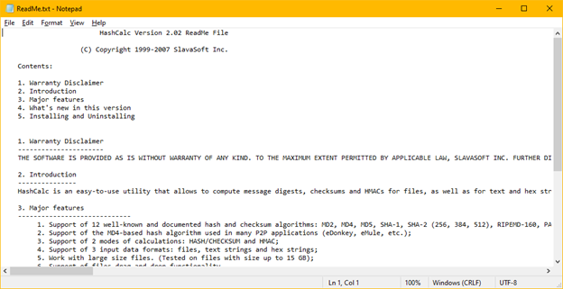

## **7**

**Lab - Compare Data with a Hash**

[figure not shown]

## **8**

**Lab - Compare Data with a Hash**

[figure not shown]

## **9**

**Lab - Compare Data with a Hash**

[figure not shown]

## **Análisis del taller Comparar datos con un hash**

**Muchos de los tipos de hash crean un hash de longitud diferente. ¿Por qué?**

**Esto se debe a que los tipos de hash utilizan diferentes algoritmos, así como también determinan diferentes longitudes.**

## **Taller 5.2.2.4 Lab - Using Digital Signatures**

**Using Digital Signatures**

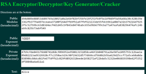

## **Taller 5.2.2.4 Lab - Using Digital Signatures**

**Using Digital Signatures**

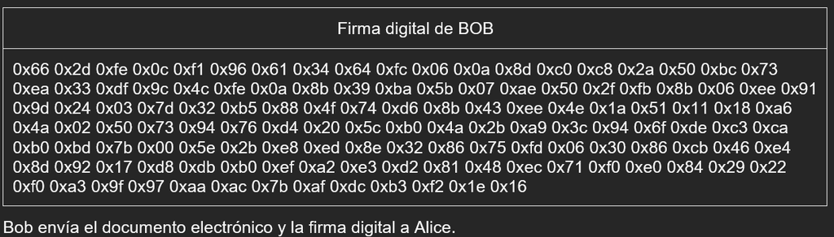

## **Taller 5.2.2.4 Lab - Using Digital Signatures**

**Using Digital Signatures**

## **Taller 5.2.2.4 Lab - Using Digital Signatures**

**Using Digital Signatures**

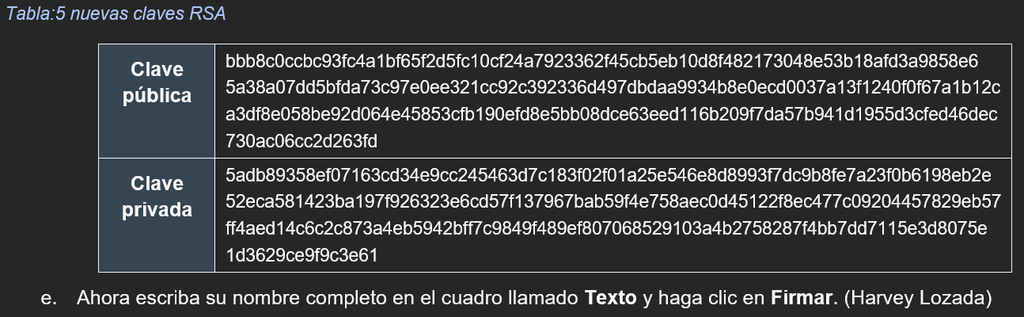

## **Taller 5.2.2.4 Lab - Using Digital Signatures**

**Using Digital Signatures**

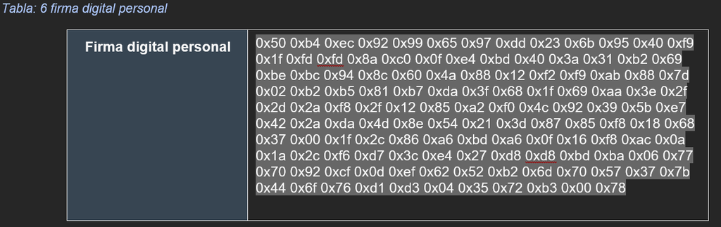

## **Taller 5.2.2.4 Lab - Using Digital Signatures**

**Para el año 2021 se presentaba un ataque por secuestro de información *(ransomware)* cada 11 segundos, se prevé que para el año 2031 los ataques serán de cada 2 segundos.**

## **Análisis por ataques en los próximos 10 años**

[figure not shown]

## **Costos por Ransomware**

**Para el año 2021 los costos por daño fueron de 20 mil millones de dólares, si los proyectamos a 10 años quiere decir que para el año 2031 podrían ser de 265 mil millones de dólares.**

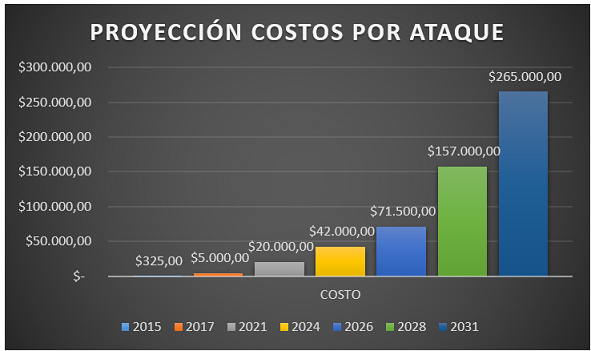

## **Fin de la presentación - Gracias**